# lin-41_abundance_6to8cell

Caroline Spike

2025-09-08

### Code to analyze lin-41 abundance in embryos with 6-8 nuclei

### Total abundance was quantified using Ce-bigFISH

### Code expects

lin-41 smFISH data for wild-type, spn-4(tn1699), ccr-4(tm1312), ccf-1(tn2132), ccf-1(tn2168rf), CCF-1 depletion (CCF1aid), let-711(tn2130) and LET-711 depletion (LET711aid) embryos with 6-8 nuclei

CebigFISH settings used to generate these data:

Voxel size in nm: 250, 65, 65

set-3 spot size in nm: 300, 110, 110

lin-41 spot size in nm: 300, 97, 97

```r
# Function to read and clean data from CSV files in subdirectories
read_data <- function(parent_directory) {

  # Function to read CSV and modify column names
  read_modify_csv <- function(file_path, subdirectory) {
    my_df <- read.csv(file_path, check.names = FALSE)  # Disable automatic name conversion
    # my_df$Image_ID <- file_path_sans_ext(basename(file_path))  # Removed to preserve actual Image ID
    my_df$subdirectory <- subdirectory

    # Remove unnecessary column if present (e.g., "X" from row indices)
    my_df <- my_df[, !colnames(my_df) %in% "X"]

    # Replace periods in column names with spaces
    colnames(my_df) <- gsub("\\.", " ", colnames(my_df))

    return(my_df)
  }

  # List all subdirectories (conditions) in the parent directory
  subdirectories <- list.dirs(parent_directory, full.names = FALSE, recursive = FALSE)

  # Initialize an empty list to store data frames
  all_data <- list()

  # Loop through subdirectories (conditions)
  for (subdirectory in subdirectories) {
    # List all CSV files in the current subdirectory
    csv_files <- list.files(path = file.path(parent_directory, subdirectory),
                            pattern = "\\.csv$", full.names = TRUE)  # Match .csv files only

    # Loop through CSV files, read data, and modify column names
    for (file_path in csv_files) {
      current_data <- read_modify_csv(file_path, subdirectory)
      all_data <- append(all_data, list(current_data))
    }
  }

  # Convert the Image_ID column to character and normalize column names
  all_data <- lapply(all_data, function(df) {
    colnames(df) <- str_replace_all(colnames(df), "[- ]", "_")  # Replace dashes and spaces with underscores
    df$Image_ID <- as.character(df$Image_ID)
    return(df)
  })

  # Combine all data frames
  combined_data <- bind_rows(all_data)

  # Filter out rows where 'lin-41_mRNA_total_molecules' is 0, if this column exists
  if ("lin_41_mRNA_total_molecules" %in% colnames(combined_data)) {
    combined_data <- combined_data %>% filter(lin_41_mRNA_total_molecules != 0)
  }

  # Make new informative columns
  combined_data <- combined_data %>%
    mutate(Nuclear_Stage = gsub("_.*", "", subdirectory),
           Strain = gsub("^(6to8_)", "", subdirectory))

  # Check the first few rows
  knitr::kable(head(combined_data))
  str(combined_data)

  # Save combined_data as a CSV file
  output_file <- file.path(parent_directory, "6to8cell_combined_quantification.csv")
  write.csv(combined_data, file = output_file, row.names = FALSE)
  message("Combined data saved at: ", output_file)

  return(combined_data)
}

# Usage example:
parent_directory <- "D:/Caroline/R_project_folders_lin41/lin41_6to8cell/data"
combined_data <- read_data(parent_directory)
```

```
## 'data.frame':    215 obs. of  6 variables:
##  $ Image_ID                   : chr  "250610_1198_crop.nd2" "250610_1203_crop.nd2" "091724_1242_crop.nd2" "091724_1248_crop.nd2" ...
##  $ set_3_mRNA_total_molecules : int  945 1005 1179 996 1248 587 950 952 622 1016 ...
##  $ lin_41_mRNA_total_molecules: int  7605 9809 10825 7779 10436 9404 9048 7843 9372 11683 ...
##  $ subdirectory               : chr  "6to8_CCF1aid" "6to8_CCF1aid" "6to8_CCF1aid" "6to8_CCF1aid" ...
##  $ Nuclear_Stage              : chr  "6to8" "6to8" "6to8" "6to8" ...
##  $ Strain                     : chr  "CCF1aid" "CCF1aid" "CCF1aid" "CCF1aid" ...
```

```
## Combined data saved at: D:/Caroline/R_project_folders_lin41/lin41_6to8cell/data/6to8cell_combined_quantification.csv
```

```r
# View combined data
knitr::kable(combined_data)
```

| Image_ID | set_3_mRNA_total_molecules | lin_41_mRNA_total_molecules | subdirectory | Nuclear_Stage | Strain |
| --- | --- | --- | --- | --- | --- |
| 250610_1198_crop.nd2 | 945 | 7605 | 6to8_CCF1aid | 6to8 | CCF1aid |
| 250610_1203_crop.nd2 | 1005 | 9809 | 6to8_CCF1aid | 6to8 | CCF1aid |
| 091724_1242_crop.nd2 | 1179 | 10825 | 6to8_CCF1aid | 6to8 | CCF1aid |
| 091724_1248_crop.nd2 | 996 | 7779 | 6to8_CCF1aid | 6to8 | CCF1aid |
| 091724_1253_crop.nd2 | 1248 | 10436 | 6to8_CCF1aid | 6to8 | CCF1aid |
| 250610_1253_crop.nd2 | 587 | 9404 | 6to8_CCF1aid | 6to8 | CCF1aid |
| 091724_1273_crop.nd2 | 950 | 9048 | 6to8_CCF1aid | 6to8 | CCF1aid |
| 091724_1277_crop.nd2 | 952 | 7843 | 6to8_CCF1aid | 6to8 | CCF1aid |
| 250611_1307_crop.nd2 | 622 | 9372 | 6to8_CCF1aid | 6to8 | CCF1aid |
| 091724_1309_crop.nd2 | 1016 | 11683 | 6to8_CCF1aid | 6to8 | CCF1aid |
| 250611_1310_crop.nd2 | 678 | 6648 | 6to8_CCF1aid | 6to8 | CCF1aid |
| 250611_1357_crop.nd2 | 1110 | 12091 | 6to8_CCF1aid | 6to8 | CCF1aid |
| 091724_1358_crop.nd2 | 1305 | 11739 | 6to8_CCF1aid | 6to8 | CCF1aid |
| 250611_1370_crop.nd2 | 778 | 8966 | 6to8_CCF1aid | 6to8 | CCF1aid |
| 250611_1399_crop.nd2 | 1060 | 10851 | 6to8_CCF1aid | 6to8 | CCF1aid |
| 250611_1404_crop.nd2 | 859 | 7872 | 6to8_CCF1aid | 6to8 | CCF1aid |
| 250611_1408_crop.nd2 | 615 | 6526 | 6to8_CCF1aid | 6to8 | CCF1aid |
| 091724_1413_crop.nd2 | 813 | 6859 | 6to8_CCF1aid | 6to8 | CCF1aid |
| 091724_1417_crop.nd2 | 875 | 6813 | 6to8_CCF1aid | 6to8 | CCF1aid |
| 091724_1421_crop.nd2 | 1006 | 9361 | 6to8_CCF1aid | 6to8 | CCF1aid |
| 091724_1518_crop.nd2 | 1201 | 11701 | 6to8_CCF1aid | 6to8 | CCF1aid |
| 091724_1535_crop.nd2 | 1051 | 8464 | 6to8_CCF1aid | 6to8 | CCF1aid |
| 091724_1547_crop.nd2 | 870 | 7820 | 6to8_CCF1aid | 6to8 | CCF1aid |
| 091724_1591_crop.nd2 | 1143 | 12471 | 6to8_CCF1aid | 6to8 | CCF1aid |
| 250610_1141_crop.nd2 | 1196 | 9411 | 6to8_CCF1aid | 6to8 | CCF1aid |
| 250610_1146_crop.nd2 | 531 | 6998 | 6to8_CCF1aid | 6to8 | CCF1aid |
| 250610_1237_crop.nd2 | 965 | 8372 | 6to8_CCF1aid | 6to8 | CCF1aid |
| 250610_1265_crop.nd2 | 729 | 8577 | 6to8_CCF1aid | 6to8 | CCF1aid |
| 091724_1341_crop.nd2 | 1125 | 10214 | 6to8_CCF1aid | 6to8 | CCF1aid |
| 250611_1345_crop.nd2 | 832 | 6580 | 6to8_CCF1aid | 6to8 | CCF1aid |

[output cut: 185 more lines]

```r
str(combined_data)
```

```
## 'data.frame':    215 obs. of  6 variables:
##  $ Image_ID                   : chr  "250610_1198_crop.nd2" "250610_1203_crop.nd2" "091724_1242_crop.nd2" "091724_1248_crop.nd2" ...
##  $ set_3_mRNA_total_molecules : int  945 1005 1179 996 1248 587 950 952 622 1016 ...
##  $ lin_41_mRNA_total_molecules: int  7605 9809 10825 7779 10436 9404 9048 7843 9372 11683 ...
##  $ subdirectory               : chr  "6to8_CCF1aid" "6to8_CCF1aid" "6to8_CCF1aid" "6to8_CCF1aid" ...
##  $ Nuclear_Stage              : chr  "6to8" "6to8" "6to8" "6to8" ...
##  $ Strain                     : chr  "CCF1aid" "CCF1aid" "CCF1aid" "CCF1aid" ...
```

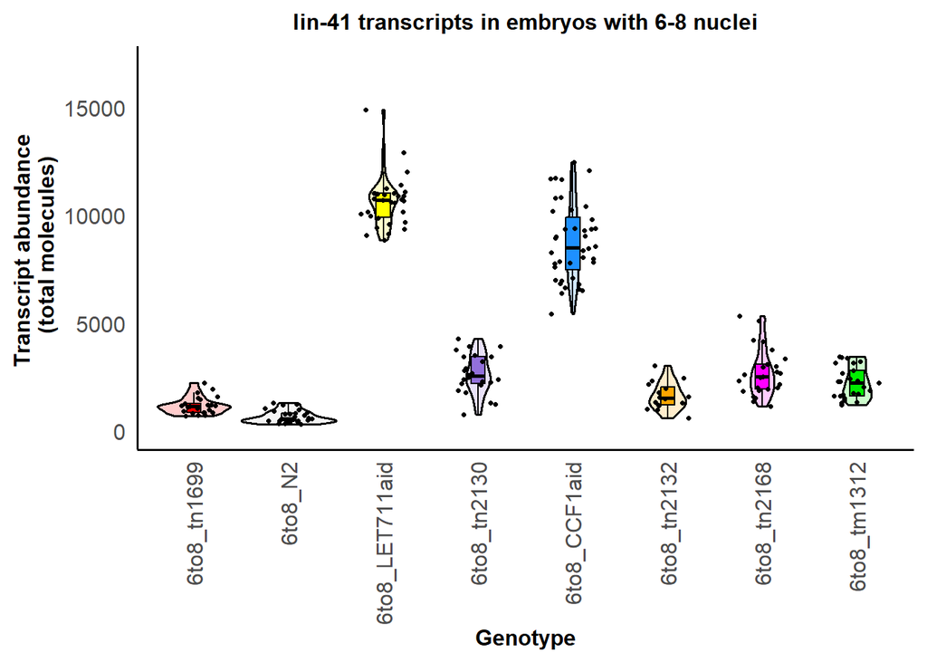

```r
# Define the custom order for subdirectories
custom_order <- c("6to8_tn1699", "6to8_N2", "6to8_LET711aid", "6to8_tn2130", "6to8_CCF1aid", "6to8_tn2132", "6to8_tn2168", "6to8_tm1312")

# Convert subdirectory to a factor with custom order
combined_data$subdirectory <- factor(combined_data$subdirectory, levels = custom_order)

# Define custom fill colors for the subdirectories
fill_colors <- c(
  "6to8_N2" = "gray80",
  "6to8_tn2132" = "orange",
  "6to8_CCF1aid" = "dodgerblue",
  "6to8_tn1699" = "red",
  "6to8_tm1312" = "green2",
  "6to8_tn2168" = "magenta",
  "6to8_tn2130" = "mediumpurple",
  "6to8_LET711aid" = "yellow"
)

# Create a combined violin and boxplot (flipped vertically)
p <- ggplot(combined_data, aes(x = factor(subdirectory, levels = custom_order), y = `lin_41_mRNA_total_molecules`, fill = subdirectory)) +
  geom_violin(alpha = 0.2, color = "black", size = 0.6, width = 1.0, position = position_dodge(width = 0.8)) +
  geom_boxplot(width = 0.15, outlier.shape = NA, color = "black", notch = "false") +
  geom_jitter(height = 0, width = 0.25, color = "black", size = 0.9) +
  labs(title = "lin-41 transcripts in embryos with 6-8 nuclei",
       x = "Genotype",
       y = "Transcript abundance \n (total molecules)") +
  scale_fill_manual(values = fill_colors) +
  theme_minimal(base_size = 14) +
  theme(axis.text.x = element_text(angle = 90, vjust = 0.5, hjust=1),  # Rotate labels on x-axis
        legend.position = "none",  # Remove legend
        panel.grid.major = element_blank(),
        panel.grid.minor = element_blank(),
        panel.border = element_blank(),
        axis.line = element_line(color = "black"),
        plot.title = element_text(hjust = 0.5, size = 12, face = "bold"),
        axis.title = element_text(size = 12, face = "bold"),
        axis.text = element_text(size = 12),
        axis.ticks = element_blank()) +
  coord_cartesian(ylim = c(0, 17000))

# Display the plot
print(p)
```

```r
# Save the plot as SVG with the date in the filename
ggsave(paste0("D:/Caroline/R_project_folders_lin41/lin41_6to8cell/output/",
              date_today, "_lin-41-mRNA-abundance-violin-plot.svg"),
       p, width = 10, height = 8)
```

Statistical analysis

Shapiro-Wilk: Test for normal distribution.

Levene: Test for equal variance.

Welch’s test: Parametric test for differences among groups. Does not assume equal variance.

Games-Howell test: A post-hoc test for Welch’s ttest.

Kruskal-Wallis: Non-parametric test for differences among groups.

Dunn test: A post-hoc test for Kruskal-Wallis. Used Benjamini-Hochberg correction for multiple testing.

Conover-Iman test: A more sensitive post-hoc test for Kruskal-Wallis. A more conservative Benjamini-Yekutieli correction for multiple testing.

```r
# Test significant differences in lin-41 mRNA abundance between each "subdirectory" ( dev. stage + strain)
# Shapiro-Wilk test for normal distributions
shapiro_result <- shapiro.test(combined_data$lin_41_mRNA_total_molecules)
by(combined_data$lin_41_mRNA_total_molecules, combined_data$subdirectory, shapiro.test)
```

```
## combined_data$subdirectory: 6to8_tn1699
##
##  Shapiro-Wilk normality test
##
## data:  dd[x, ]
## W = 0.90416, p-value = 0.02263
##
## --------------------------------------------------------------------------------------------------------------------------
## combined_data$subdirectory: 6to8_N2
##
##  Shapiro-Wilk normality test
##
## data:  dd[x, ]
## W = 0.89452, p-value = 0.00726
##
## --------------------------------------------------------------------------------------------------------------------------
## combined_data$subdirectory: 6to8_LET711aid
##
##  Shapiro-Wilk normality test
##
## data:  dd[x, ]
## W = 0.87088, p-value = 0.001459
##
## --------------------------------------------------------------------------------------------------------------------------
## combined_data$subdirectory: 6to8_tn2130
##
##  Shapiro-Wilk normality test
##
## data:  dd[x, ]
## W = 0.97689, p-value = 0.8323
##
## --------------------------------------------------------------------------------------------------------------------------
## combined_data$subdirectory: 6to8_CCF1aid
##
##  Shapiro-Wilk normality test
##
## data:  dd[x, ]
## W = 0.96609, p-value = 0.2687
##
## --------------------------------------------------------------------------------------------------------------------------
## combined_data$subdirectory: 6to8_tn2132
##
##  Shapiro-Wilk normality test
##
## data:  dd[x, ]
## W = 0.96828, p-value = 0.81
##
## --------------------------------------------------------------------------------------------------------------------------
## combined_data$subdirectory: 6to8_tn2168
##
##  Shapiro-Wilk normality test
##
## data:  dd[x, ]
## W = 0.92625, p-value = 0.07124
##
## --------------------------------------------------------------------------------------------------------------------------
## combined_data$subdirectory: 6to8_tm1312
##
##  Shapiro-Wilk normality test
##
## data:  dd[x, ]
## W = 0.91793, p-value = 0.04597
```

```r
# Test homogeneity of variance using Levene's Test.
leveneTest(lin_41_mRNA_total_molecules ~ subdirectory, data = combined_data)
```

```
## Levene's Test for Homogeneity of Variance (center = median)
##        Df F value    Pr(>F)
## group   7  11.139 6.098e-12 ***
##       207
## ---
## Signif. codes:  0 '***' 0.001 '**' 0.01 '*' 0.05 '.' 0.1 ' ' 1
```

```r
# Welch's ANOVA: a parametric test that does not assume equal variance
oneway.test(lin_41_mRNA_total_molecules ~ subdirectory, data = combined_data)
```

```
##
##  One-way analysis of means (not assuming equal variances)
##
## data:  lin_41_mRNA_total_molecules and subdirectory
## F = 390.09, num df = 7.000, denom df = 79.811, p-value < 2.2e-16
```

```r
# Games Howell: a post-hoc test for Welch's ANOVA
# Games-Howell test
games_results <- combined_data %>%
  games_howell_test(lin_41_mRNA_total_molecules ~ subdirectory)

# Display Games-Howell post hoc test results
games_results_df <- as.data.frame(games_results)
games_results_df %>%
  dplyr::select(group1, group2, estimate, p.adj, p.adj.signif) %>%
  print()
```

```
##            group1         group2    estimate    p.adj p.adj.signif
## 1     6to8_tn1699        6to8_N2  -524.05793 4.27e-05         ****
## 2     6to8_tn1699 6to8_LET711aid  9448.43484 0.00e+00         ****
## 3     6to8_tn1699    6to8_tn2130  1462.78833 1.04e-06         ****
## 4     6to8_tn1699   6to8_CCF1aid  7575.18000 3.41e-13         ****
## 5     6to8_tn1699    6to8_tn2132   440.26750 2.44e-01           ns
## 6     6to8_tn1699    6to8_tn2168  1526.40000 8.73e-06         ****
## 7     6to8_tn1699    6to8_tm1312  1053.48000 6.27e-06         ****
## 8         6to8_N2 6to8_LET711aid  9972.49277 2.22e-16         ****
## 9         6to8_N2    6to8_tn2130  1986.84626 2.49e-09         ****
## 10        6to8_N2   6to8_CCF1aid  8099.23793 1.02e-12         ****
## 11        6to8_N2    6to8_tn2132   964.32543 3.34e-04          ***
## 12        6to8_N2    6to8_tn2168  2050.45793 3.49e-08         ****
## 13        6to8_N2    6to8_tm1312  1577.53793 9.22e-10         ****
## 14 6to8_LET711aid    6to8_tn2130 -7985.64651 0.00e+00         ****
## 15 6to8_LET711aid   6to8_CCF1aid -1873.25484 3.48e-05         ****
## 16 6to8_LET711aid    6to8_tn2132 -9008.16734 2.89e-13         ****
## 17 6to8_LET711aid    6to8_tn2168 -7922.03484 0.00e+00         ****
## 18 6to8_LET711aid    6to8_tm1312 -8394.95484 0.00e+00         ****
## 19    6to8_tn2130   6to8_CCF1aid  6112.39167 2.04e-11         ****
## 20    6to8_tn2130    6to8_tn2132 -1022.52083 4.00e-03           **
## 21    6to8_tn2130    6to8_tn2168    63.61167 1.00e+00           ns
## 22    6to8_tn2130    6to8_tm1312  -409.30833 6.72e-01           ns
## 23   6to8_CCF1aid    6to8_tn2132 -7134.91250 0.00e+00         ****
## 24   6to8_CCF1aid    6to8_tn2168 -6048.78000 1.53e-11         ****
## 25   6to8_CCF1aid    6to8_tm1312 -6521.70000 8.86e-12         ****
## 26    6to8_tn2132    6to8_tn2168  1086.13250 6.00e-03           **
## 27    6to8_tn2132    6to8_tm1312   613.21250 1.15e-01           ns
## 28    6to8_tn2168    6to8_tm1312  -472.92000 6.36e-01           ns
```

```r
# Kruskal-Wallis is a non-parametric test that may be more appropriate. The distributions of four subgroups deviate significantly from normality.
kruskal.test(lin_41_mRNA_total_molecules ~ subdirectory, data = combined_data)
```

```
##
##  Kruskal-Wallis rank sum test
##
## data:  lin_41_mRNA_total_molecules by subdirectory
## Kruskal-Wallis chi-squared = 186.34, df = 7, p-value < 2.2e-16
```

```r
# Use the Dunn test to determine significance between groups.
dunn_results <- combined_data %>%
  dunn_test(lin_41_mRNA_total_molecules ~ subdirectory, p.adjust.method = "BH")

# Summarize the results of the Dunn test.
dunn_results %>%
  dplyr::mutate(
    p.adj = signif(p.adj, 3)
  ) %>%
  dplyr::select(group1, group2, p.adj, p.adj.signif) %>%
  dplyr::arrange(p.adj) %>%
  print(n = Inf)
```

```
## # A tibble: 28 × 4
##    group1         group2            p.adj p.adj.signif
##    <chr>          <chr>             <dbl> <chr>
##  1 6to8_N2        6to8_LET711aid 2.31e-25 ****
##  2 6to8_N2        6to8_CCF1aid   4.56e-22 ****
##  3 6to8_tn1699    6to8_LET711aid 4.16e-17 ****
##  4 6to8_tn1699    6to8_CCF1aid   5.52e-14 ****
##  5 6to8_LET711aid 6to8_tn2132    9.24e-10 ****
##  6 6to8_LET711aid 6to8_tm1312    2.57e- 8 ****
##  7 6to8_CCF1aid   6to8_tn2132    1.79e- 7 ****
##  8 6to8_LET711aid 6to8_tn2168    7.61e- 7 ****
##  9 6to8_N2        6to8_tn2130    1.19e- 6 ****
## 10 6to8_N2        6to8_tn2168    1.19e- 6 ****
## 11 6to8_LET711aid 6to8_tn2130    1.19e- 6 ****
## 12 6to8_CCF1aid   6to8_tm1312    4.1 e- 6 ****
```

[output cut: 16 more lines]

```r
# Save Dunn's output as a csv
dunn_summary <- dunn_results %>%
  dplyr::mutate(
    p.adj = signif(p.adj, 3)
  ) %>%
  dplyr::select(group1, group2, p.adj, p.adj.signif) %>%
  dplyr::arrange(p.adj)

write.csv(dunn_summary,
          file = paste0("D:/Caroline/R_project_folders_lin41/lin41_6to8cell/output/", date_today, "_dunn_results.csv"),
          row.names = FALSE)

# Run Conover-Iman test with Benjamini-Yekutieli correction to determine significance between groups.
conover_result <- kwAllPairsConoverTest(lin_41_mRNA_total_molecules ~ subdirectory,
                                data = combined_data,
                                p.adjust.method = "BY")

# Display Conover-Iman post hoc test results
print(conover_result)
```

```
##
##  Pairwise comparisons using Conover's all-pairs test
```

```
## data: lin_41_mRNA_total_molecules by subdirectory
```

```
##                6to8_tn1699 6to8_N2 6to8_LET711aid 6to8_tn2130 6to8_CCF1aid 6to8_tn2132 6to8_tn2168
## 6to8_N2        8.4e-05     -       -              -           -            -           -
## 6to8_LET711aid < 2e-16     < 2e-16 -              -           -            -           -
## 6to8_tn2130    5.1e-16     < 2e-16 < 2e-16        -           -            -           -
## 6to8_CCF1aid   < 2e-16     < 2e-16 0.00044        < 2e-16     -            -           -
## 6to8_tn2132    0.00980     1.6e-10 < 2e-16        7.1e-06     < 2e-16      -           -
## 6to8_tn2168    6.6e-16     < 2e-16 < 2e-16        1.00000     < 2e-16      1.0e-05     -
## 6to8_tm1312    2.4e-11     < 2e-16 < 2e-16        0.30578     < 2e-16      0.00349     0.38284
```

```
##
## P value adjustment method: BY
```

```r
# Extract and convert Conover-Iman results to a data frame
conover_summary <- as.data.frame(conover_result$p.value)

# Save to CSV
write.csv(conover_summary,
          file = paste0("D:/Caroline/R_project_folders_lin41/lin41_6to8cell/output/",
                        date_today, "_conover_results.csv"),
          row.names = TRUE)

# Summarize important metrics that describe the underlying data.
combined_data %>%
  group_by(subdirectory) %>%
  summarize(mean = mean(lin_41_mRNA_total_molecules),
            median = median(lin_41_mRNA_total_molecules),
            sd = sd(lin_41_mRNA_total_molecules),
            n = n())
```

```
## # A tibble: 8 × 5
##   subdirectory     mean median    sd     n
##   <fct>           <dbl>  <dbl> <dbl> <int>
## 1 6to8_tn1699     1200.  1159   391.    25
## 2 6to8_N2          676.   571   285.    29
## 3 6to8_LET711aid 10648. 10716  1185.    31
## 4 6to8_tn2130     2663.  2552.  914.    24
## 5 6to8_CCF1aid    8775.  8520. 1779.    40
## 6 6to8_tn2132     1640.  1536.  630.    16
## 7 6to8_tn2168     2726.  2533  1105.    25
## 8 6to8_tm1312     2253.  2237   735.    25
```